# Analysis & Visualizations

John Cruz

3-16-2022

## Introduction.

This work is the fourth of five stages of an analysis where the main objective was to identify the most valued data science skills. Our approach to this was to collect job postings from various job boards and extract the skills from the postings. The purpose of this specific file’s work is to analyze the skills extracted from the job postings.

## Read in data

Read the data from a CSV file which contains job listings and skills

```r
import_df <- read_csv('output/job_listings_skills_long.csv')
```

## Job Listings Based on Data Source

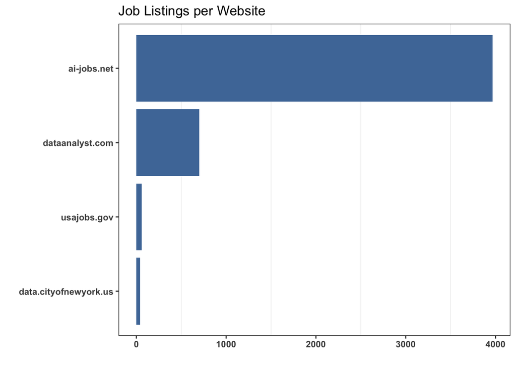

```r
distinct_job_website <-
  import_df |>
  group_by(website) |>
  summarise(count = n_distinct(job_id)) |>
  arrange(desc(count))

ggplot(distinct_job_website, aes(x = count, y = reorder(website, count))) +
  geom_bar(stat = 'identity', fill = '#4E79A7') +
  labs(title = "Job Listings per Website", x = '', y = '') +
  theme_bw() +
  theme(panel.grid.major = element_blank(),
        axis.text = element_text(face = 'bold'))
```

```r
knitr::kable(distinct_job_website)
```

| website | count |
| --- | --- |
| ai-jobs.net | 3967 |
| dataanalyst.com | 700 |
| usajobs.gov | 58 |
| data.cityofnewyork.us | 44 |

## Most Requested Degree

Based on the job postings that had college degree information, having a Master’s was first at 498, followed by a Bachelor’s at 456.

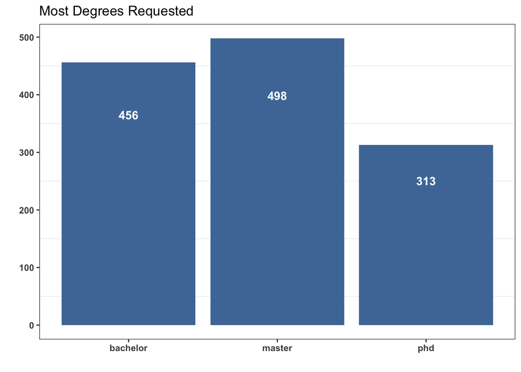

```r
high_degree <-
  import_df |>
  na.omit(highest_ed) %>%
  group_by(highest_ed) %>%
  summarize(count = n_distinct(job_id))

high_degree %>%
  ggplot(aes(x = highest_ed, y = count)) +
  geom_bar(stat = 'identity', fill = '#4E79A7') +
  labs(title = "Most Degrees Requested", x = '', y = '') +
  theme_bw() +
  theme(panel.grid.major = element_blank(),
        axis.text = element_text(face = 'bold')) +
  geom_text(aes(label = count),
            position = position_stack(vjust = 0.8),
            size = 4,
            fontface = 'bold',
            color = 'white')
```

```r
knitr::kable(high_degree)
```

| highest_ed | count |
| --- | --- |
| bachelor | 456 |
| master | 498 |
| phd | 313 |

## Maximum Salary Distribution

The histogram shows the distribution of maximum salary values for all jobs within the dataset, with missing values removed. We can see that there is a bi-modal distribution where it peaks first at $125,000 and again at $175,000.

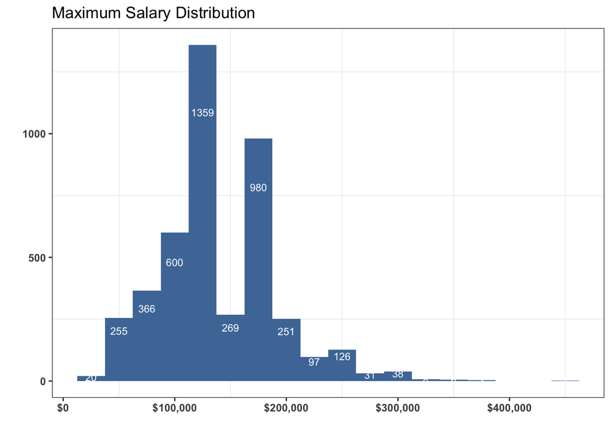

```r
salaries <-
  import_df |>
  filter(!is.na(salary_max)) |>
  distinct(job_id, .keep_all = TRUE)


salaries |>
  ggplot(aes(x = salary_max)) +
  geom_histogram(binwidth = 25000, fill = '#4E79A7') +
  scale_x_continuous(labels = scales::dollar) +
  labs(title = "Maximum Salary Distribution", x = '', y = '') +
  theme_bw() +
  theme(panel.grid.major = element_blank(),
        axis.text = element_text(face = 'bold')) +
  stat_bin(binwidth=25000, geom='text', color='white', size=3,
           aes(label=after_stat(count)), position=position_stack(vjust=0.8))
```

## Maximum Salary Distribution vs. Education

Separating our bi-modal distribution based on education, we can still see the same type of distribution and peaks as before.

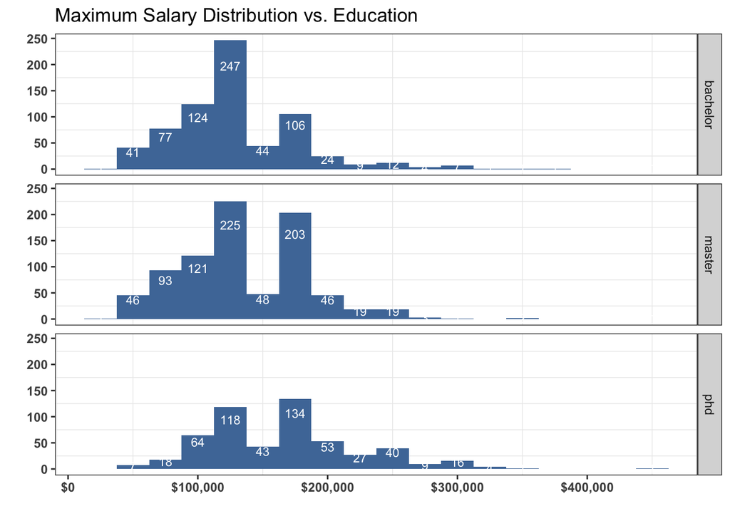

```r
salaries_edu <-
  import_df |>
  filter(!is.na(salary_max), !is.na(highest_ed)) |>
  distinct(job_id, .keep_all = TRUE)


salaries_edu |>
  ggplot(aes(x = salary_max)) +
  geom_histogram(binwidth = 25000, fill = '#4E79A7') +
  scale_x_continuous(labels = scales::dollar) +
  labs(title = "Maximum Salary Distribution vs. Education", x = '', y = '') +
  theme_bw() +
  theme(panel.grid.major = element_blank(),
        axis.text = element_text(face = 'bold')) +
  stat_bin(binwidth=25000, geom='text', color='white', size=3,
           aes(label=after_stat(count)), position=position_stack(vjust=0.8)) +
  facet_grid(rows = vars(highest_ed))
```

## Maximum Salary Distribution vs. Years of Experience

Separating our bi-modal distribution based on years of experience, we again can still see the same type of distribution and peaks as before.

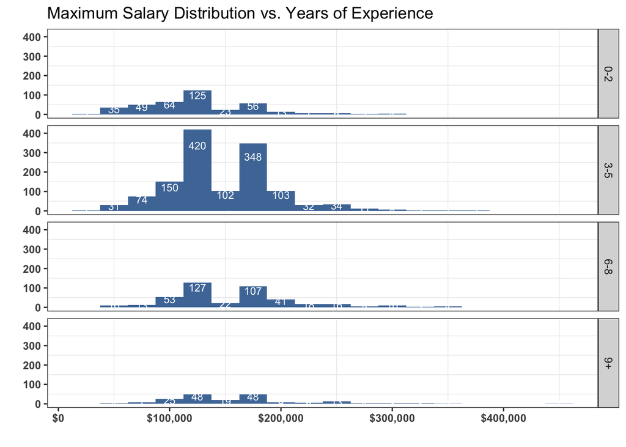

```r
salaries_exp <-
  import_df |>
  filter(!is.na(salary_max), !is.na(years_exp)) |>
  distinct(job_id, .keep_all = TRUE) |>
  mutate(exp_bins = case_when(years_exp <= 2 ~ "0-2",
                              years_exp > 2 & years_exp <= 5 ~ "3-5",
                              years_exp > 5 & years_exp <= 8 ~ "6-8",
                              years_exp > 8  ~ "9+")) |>
  mutate(across(c(exp_bins), factor))


salaries_exp |>
  ggplot(aes(x = salary_max)) +
  geom_histogram(binwidth = 25000, fill = '#4E79A7') +
  scale_x_continuous(labels = scales::dollar) +
  labs(title = "Maximum Salary Distribution vs. Years of Experience", x = '', y = '') +
  theme_bw() +
  theme(panel.grid.major = element_blank(),
        axis.text = element_text(face = 'bold')) +
  stat_bin(binwidth=25000, geom='text', color='white', size=3,
           aes(label=after_stat(count)), position=position_stack(vjust=0.8)) +
  facet_grid(rows = vars(exp_bins))
```

## Education and Years of Experience

Based on the chart, we can identify that most jobs primarily look for candidates with 3-5 years of experience. However, the plot also suggests that there are differences in the distribution of years of experience within each educational level. For example, among individuals with a Bachelor’s degree, the distribution of years of experience appears to be skewed towards the lower end, suggesting that many individuals in these positions have relatively little experience. On the other hand, among individuals with a PhD, the distribution of years of experience appears to be more evenly spread out, suggesting that individuals with a PhD may have more varied levels of experience.

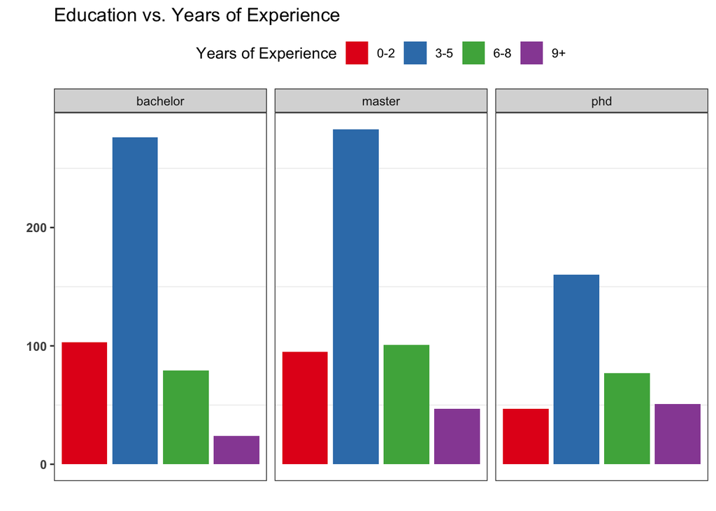

```r
edu_exp <-
  import_df |>
  filter(!is.na(highest_ed), !is.na(years_exp)) |>
  distinct(job_id, .keep_all = TRUE) |>
  mutate(exp_bins = case_when(years_exp <= 2 ~ "0-2",
                              years_exp > 2 & years_exp <= 5 ~ "3-5",
                              years_exp > 5 & years_exp <= 8 ~ "6-8",
                              years_exp > 8  ~ "9+")) |>
  mutate(across(c(exp_bins), factor))

edu_exp |> ggplot(aes(exp_bins)) +
  geom_bar(aes(fill = exp_bins)) +
  facet_grid(~highest_ed,
             labeller = label_wrap_gen(width=2, multi_line=TRUE)) +
  labs(title = "Education vs. Years of Experience",
       x = '', y = '',
       fill = "Years of Experience") +
  theme_bw() +
  theme(panel.grid.major = element_blank(),
        axis.text = element_text(face = 'bold'),
        axis.text.x=element_blank(),
        axis.ticks.x=element_blank(),
        legend.position="top") +
  scale_fill_brewer(palette = 'Set1')
```

## Top 20 Most Frequently Cited Skills

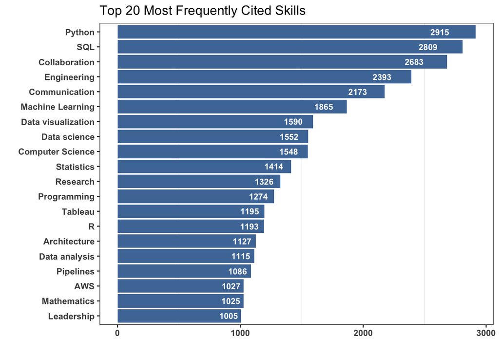

```r
skill_counts <- import_df %>%
  group_by(skill) %>%
  summarize(count = n(), .groups = 'keep') |>
  filter(!skill %in% c('engineering', 'data science', 'research', 'programming')) |>
  arrange(desc(count))

skill_counts |>
  head(20) |>
  ggplot(aes(x = count, y = reorder(skill, count))) +
  geom_bar(stat = 'identity', fill = '#4E79A7') +
    labs(title = "Top 20 Most Frequently Cited Skills", x = '', y = '') +
  theme_bw() +
  theme(panel.grid.major = element_blank(),
        axis.text = element_text(face = 'bold')) +
  geom_text(aes(label = count),
            position = position_stack(vjust = 0.9),
            size = 3,
            fontface = 'bold',
            color = 'white')
```

```r
knitr::kable(skill_counts |> head(20))
```

| skill | count |
| --- | --- |
| Python | 2915 |
| SQL | 2809 |
| Collaboration | 2683 |
| Engineering | 2393 |
| Communication | 2173 |
| Machine Learning | 1865 |
| Data visualization | 1590 |
| Data science | 1552 |
| Computer Science | 1548 |
| Statistics | 1414 |
| Research | 1326 |
| Programming | 1274 |
| Tableau | 1195 |
| R | 1193 |
| Architecture | 1127 |
| Data analysis | 1115 |
| Pipelines | 1086 |
| AWS | 1027 |
| Mathematics | 1025 |
| Leadership | 1005 |

## What are the top 10 most important skills for data science?

```r
top_10 <- import_df %>%
  count(skill) %>%
  arrange(desc(n)) %>%
  head(n = 10)

knitr::kable(top_10, col.names = c("Skills", "Count"), format.args = list(big.mark = ","))
```

| Skills | Count |
| --- | --- |
| Python | 2,915 |
| SQL | 2,809 |
| Collaboration | 2,683 |
| Engineering | 2,393 |
| Communication | 2,173 |
| Machine Learning | 1,865 |
| Data visualization | 1,590 |
| Data science | 1,552 |
| Computer Science | 1,548 |
| Statistics | 1,414 |

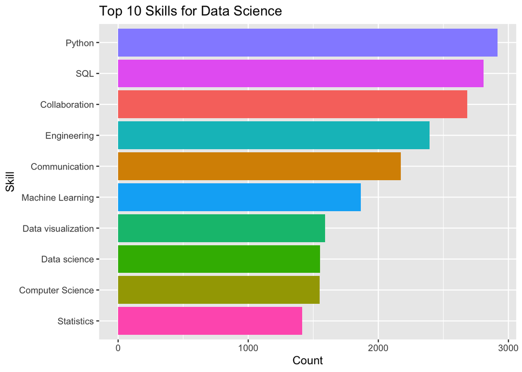

```r
top_10 %>%
  ggplot(aes(y = reorder(skill, n), x = n, fill = skill)) +
    geom_bar(stat = "identity") +
    labs(title = "Top 10 Skills for Data Science", x = "Count", y = "Skill") +
    theme(legend.position = "none")
```